# Time Series Assignment 2

Anusha Bhat

2025-01-22

```r
library(tseries)
library(DataCombine)
```

```r
# load data
stocks = read.csv("C:\\Users\\anush\\Downloads\\TS regression - data_akbilgic.csv")

stocks$date = as.Date(stocks$date, format="%d-%b-%y")

head(stocks)
```

```
##         date          ISE           SP          DAX         FTSE       NIKKEI
## 1 2009-01-05  0.038376187 -0.004679315  0.002193419  0.003894376  0.000000000
## 2 2009-01-06  0.031812743  0.007786738  0.008455341  0.012865611  0.004162452
## 3 2009-01-07 -0.026352966 -0.030469134 -0.017833062 -0.028734593  0.017292932
## 4 2009-01-08 -0.084715902  0.003391364 -0.011726277 -0.000465999 -0.040061309
## 5 2009-01-09  0.009658112 -0.021533208 -0.019872754 -0.012709717 -0.004473502
## 6 2009-01-12 -0.042361155 -0.022822626 -0.013525735 -0.005025533 -0.049038532
##       BOVESPA
## 1  0.03119023
## 2  0.01891958
## 3 -0.03589858
## 4  0.02828315
## 5 -0.00976388
## 6 -0.05384947
```

## Question 1.1:

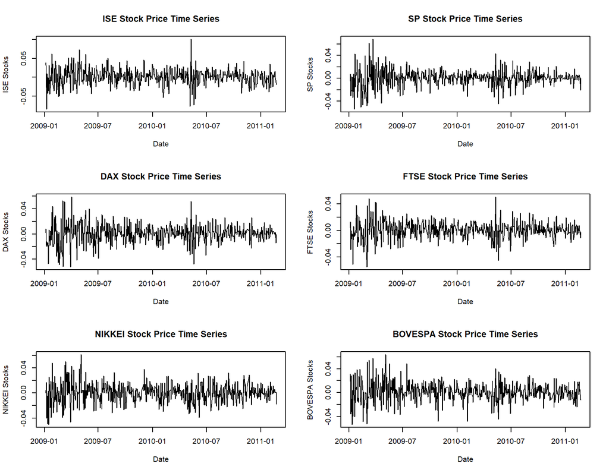

```r
par(mfrow = c(3, 2))

# create time series plot for each stock
plot(stocks$date, stocks$ISE, type='l',
     xlab = 'Date', ylab = 'ISE Stocks',
     main = 'ISE Stock Price Time Series')

plot(stocks$date, stocks$SP, type='l',
     xlab = 'Date', ylab = 'SP Stocks',
     main = 'SP Stock Price Time Series')

plot(stocks$date, stocks$DAX, type='l',
     xlab = 'Date', ylab = 'DAX Stocks',
     main = 'DAX Stock Price Time Series')

plot(stocks$date, stocks$FTSE, type='l',
     xlab = 'Date', ylab = 'FTSE Stocks',
     main = 'FTSE Stock Price Time Series')

plot(stocks$date, stocks$NIKKEI, type='l',
     xlab = 'Date', ylab = 'NIKKEI Stocks',
     main = 'NIKKEI Stock Price Time Series')

plot(stocks$date, stocks$BOVESPA, type='l',
     xlab = 'Date', ylab = 'BOVESPA Stocks',
     main = 'BOVESPA Stock Price Time Series')
```

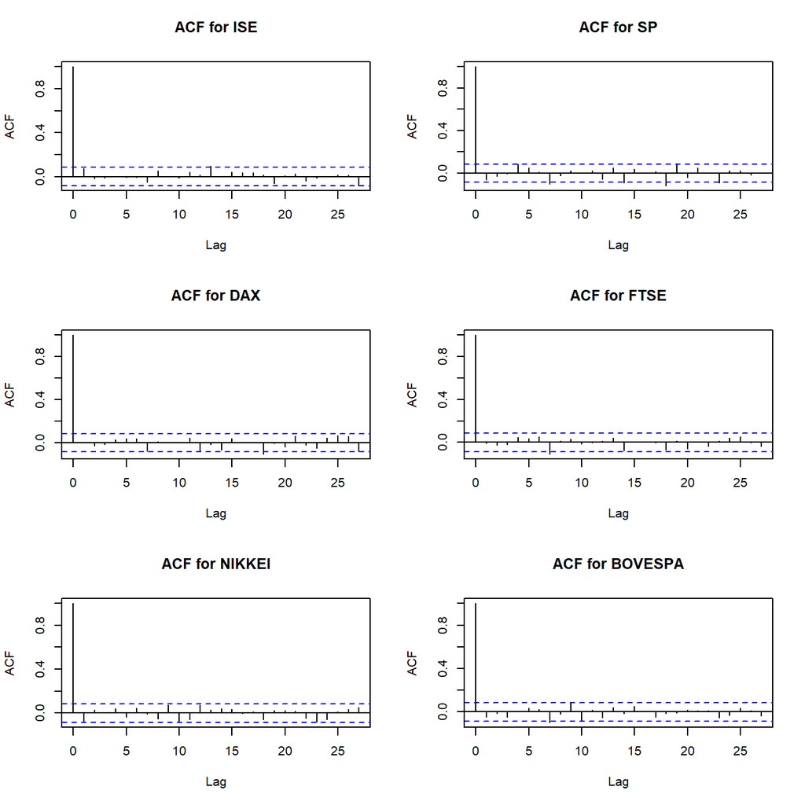

```r
par(mfrow = c(3, 2))

# ACF plots for each stock
acf(stocks$ISE, main = "ACF for ISE")
acf(stocks$SP, main = "ACF for SP")
acf(stocks$DAX, main = "ACF for DAX")
acf(stocks$FTSE, main = "ACF for FTSE")
acf(stocks$NIKKEI, main = "ACF for NIKKEI")
acf(stocks$BOVESPA, main = "ACF for BOVESPA")
```

For each of the time series plots, there appears to be no trends and the lines are all centered around an index of 0, indicating a potentially constant mean for each stock. There seems to be some variance, however, the ACF plots are relatively constant for each stock. This indicates that qualitatively all of the stocks may be stationary.

## Question 1.2

```r
adf.test(stocks$ISE,alternative='stationary')
```

```
##
##  Augmented Dickey-Fuller Test
##
## data:  stocks$ISE
## Dickey-Fuller = -7.9492, Lag order = 8, p-value = 0.01
## alternative hypothesis: stationary
```

```r
kpss.test(stocks$ISE,null='Level')
```

```
##
##  KPSS Test for Level Stationarity
##
## data:  stocks$ISE
## KPSS Level = 0.1967, Truncation lag parameter = 6, p-value = 0.1
```

```r
adf.test(stocks$SP,alternative='stationary')
```

```
##
##  Augmented Dickey-Fuller Test
##
## data:  stocks$SP
## Dickey-Fuller = -8.1353, Lag order = 8, p-value = 0.01
## alternative hypothesis: stationary
```

```r
kpss.test(stocks$SP,null='Level')
```

```
##
##  KPSS Test for Level Stationarity
##
## data:  stocks$SP
## KPSS Level = 0.08007, Truncation lag parameter = 6, p-value = 0.1
```

```r
adf.test(stocks$DAX,alternative='stationary')
```

```
##
##  Augmented Dickey-Fuller Test
##
## data:  stocks$DAX
## Dickey-Fuller = -8.147, Lag order = 8, p-value = 0.01
## alternative hypothesis: stationary
```

```r
kpss.test(stocks$DAX,null='Level')
```

```
##
##  KPSS Test for Level Stationarity
##
## data:  stocks$DAX
## KPSS Level = 0.079887, Truncation lag parameter = 6, p-value = 0.1
```

```r
adf.test(stocks$FTSE,alternative='stationary')
```

```
##
##  Augmented Dickey-Fuller Test
##
## data:  stocks$FTSE
## Dickey-Fuller = -7.8456, Lag order = 8, p-value = 0.01
## alternative hypothesis: stationary
```

```r
kpss.test(stocks$FTSE,null='Level')
```

```
##
##  KPSS Test for Level Stationarity
##
## data:  stocks$FTSE
## KPSS Level = 0.078836, Truncation lag parameter = 6, p-value = 0.1
```

```r
adf.test(stocks$NIKKEI,alternative='stationary')
```

```
##
##  Augmented Dickey-Fuller Test
##
## data:  stocks$NIKKEI
## Dickey-Fuller = -7.7679, Lag order = 8, p-value = 0.01
## alternative hypothesis: stationary
```

```r
kpss.test(stocks$NIKKEI,null='Level')
```

```
##
##  KPSS Test for Level Stationarity
##
## data:  stocks$NIKKEI
## KPSS Level = 0.061547, Truncation lag parameter = 6, p-value = 0.1
```

```r
adf.test(stocks$BOVESPA,alternative='stationary')
```

```
##
##  Augmented Dickey-Fuller Test
##
## data:  stocks$BOVESPA
## Dickey-Fuller = -7.7122, Lag order = 8, p-value = 0.01
## alternative hypothesis: stationary
```

```r
kpss.test(stocks$BOVESPA,null='Level')
```

```
##
##  KPSS Test for Level Stationarity
##
## data:  stocks$BOVESPA
## KPSS Level = 0.26752, Truncation lag parameter = 6, p-value = 0.1
```

To assess stationarity quantitatively, we can conduct ADF and KPSS tests. For each stock, the ADF test returns a p-value < 0.01, which is less than an alpha level of 0.05, so we reject the null hypothesis that the stocks are not stationary in favor of the alternative hypothesis that they are stationary. Similarly, the KPSS test for each stock returns a p-value > 0 .1 which is greater than the alpha level of 0.05, so we fail to reject the null hypothesis that the stocks are stationary for each test. Therefore, a quantitative assessment of each stock reveals that they are all stationary.

## Question 2:

```r
# keep all rows except for last 10
train = stocks[1:(nrow(stocks)-10),]
head(train)
```

```
##         date          ISE           SP          DAX         FTSE       NIKKEI
## 1 2009-01-05  0.038376187 -0.004679315  0.002193419  0.003894376  0.000000000
## 2 2009-01-06  0.031812743  0.007786738  0.008455341  0.012865611  0.004162452
## 3 2009-01-07 -0.026352966 -0.030469134 -0.017833062 -0.028734593  0.017292932
## 4 2009-01-08 -0.084715902  0.003391364 -0.011726277 -0.000465999 -0.040061309
## 5 2009-01-09  0.009658112 -0.021533208 -0.019872754 -0.012709717 -0.004473502
## 6 2009-01-12 -0.042361155 -0.022822626 -0.013525735 -0.005025533 -0.049038532
##       BOVESPA
## 1  0.03119023
## 2  0.01891958
## 3 -0.03589858
## 4  0.02828315
## 5 -0.00976388
## 6 -0.05384947
```

```r
nrow(stocks) - nrow(train) == 10 # check row count
```

```
## [1] TRUE
```

```r
test = stocks[(nrow(stocks)-9):nrow(stocks),]
test # check dates are correct for these 10 rows (after Feb 9th)
```

```
##           date          ISE           SP          DAX         FTSE       NIKKEI
## 527 2011-02-09 -0.003254870 -0.002789697 -0.000319582 -0.006423159 -0.001707929
## 528 2011-02-10 -0.024920602  0.000749220  0.002643718 -0.005351106 -0.001147786
## 529 2011-02-11  0.006418220  0.005492239  0.004203526  0.007100974  0.011240935
## 530 2011-02-14  0.000404514  0.002382143  0.003443976 -0.000461932  0.000000000
## 531 2011-02-15  0.000892722 -0.003240202  0.000460915 -0.003802537  0.001968126
## 532 2011-02-16  0.013399898  0.006237986  0.001925162  0.007952263  0.005717493
## 533 2011-02-17  0.015977203  0.003070891 -0.001186250  0.000345034  0.002619553
## 534 2011-02-18 -0.001652602  0.001922906  0.002872108 -0.000723066  0.000568280
## 535 2011-02-21 -0.013705988 -0.020742153 -0.014238861 -0.011274897  0.001357583
## 536 2011-02-22 -0.019441850  0.000000000 -0.000472672 -0.002997105 -0.017919626
##          BOVESPA
## 527 -0.023895466
## 528  0.005590250
## 529  0.018077126
## 530  0.012122826
## 531 -0.003265641
## 532  0.018370790
## 533  0.001685693
## 534  0.005627925
## 535 -0.011941676
## 536 -0.012251554
```

## Question 3:

```r
# linearly regressing ISE on the 5 other stocks
mod = lm(ISE ~ SP + DAX + FTSE + NIKKEI + BOVESPA,
         data = train)
summary(mod)
```

```
##
## Call:
## lm(formula = ISE ~ SP + DAX + FTSE + NIKKEI + BOVESPA, data = train)
##
## Residuals:
##       Min        1Q    Median        3Q       Max
## -0.071180 -0.009248  0.000083  0.009304  0.051863
##
## Coefficients:
##               Estimate Std. Error t value Pr(>|t|)
## (Intercept)  0.0008833  0.0006640   1.330 0.183979
## SP          -0.0607521  0.0770823  -0.788 0.430970
## DAX          0.3417440  0.0961243   3.555 0.000412 ***
## FTSE         0.6033493  0.1077621   5.599 3.50e-08 ***
## NIKKEI       0.3266529  0.0462163   7.068 5.09e-12 ***
## BOVESPA      0.1117630  0.0626647   1.784 0.075087 .
## ---
## Signif. codes:  0 '***' 0.001 '**' 0.01 '*' 0.05 '.' 0.1 ' ' 1
##
## Residual standard error: 0.0152 on 520 degrees of freedom
## Multiple R-squared:  0.493,  Adjusted R-squared:  0.4881
## F-statistic: 101.1 on 5 and 520 DF,  p-value: < 2.2e-16
```

The coefficients for DAX, FTSE, and NIKKEI all have a p-value < 0.02, indicating that these are the 3 significant predictors for this linear regression. SP and BOVESPA are the non-significant predictors.

## Question 4:

```r
# copy train data for lagging
data = train
```

```r
# lag SP rerun the regression then lag BOVESPA and rerun the regression
# redo this process until we get the desired results
# note: this is the final lag results

data = slide(data, Var = "SP", slideBy = -2,
             NewVar = "SP_lag")
```

```
##
## Remember to put data in time order before running.
```

```
##
## Lagging SP by 2 time units.
```

```r
data = slide(data, Var = "BOVESPA", slideBy = -1,
             NewVar = "BOVESPA_lag")
```

```
##
## Remember to put data in time order before running.
```

```
##
## Lagging BOVESPA by 1 time units.
```

```r
mod2 = lm(ISE ~ SP_lag + DAX + FTSE + NIKKEI + BOVESPA_lag,
         data = data)
summary(mod2)
```

```
##
## Call:
## lm(formula = ISE ~ SP_lag + DAX + FTSE + NIKKEI + BOVESPA_lag,
##     data = data)
##
## Residuals:
##       Min        1Q    Median        3Q       Max
## -0.063412 -0.009491  0.000468  0.008739  0.050599
##
## Coefficients:
##               Estimate Std. Error t value Pr(>|t|)
## (Intercept)  0.0007513  0.0006491   1.157 0.247635
## SP_lag      -0.1082670  0.0455658  -2.376 0.017861 *
## DAX          0.3355329  0.0890788   3.767 0.000184 ***
## FTSE         0.6368064  0.1024472   6.216 1.05e-09 ***
## NIKKEI       0.2395311  0.0489366   4.895 1.32e-06 ***
## BOVESPA_lag  0.2057244  0.0452856   4.543 6.91e-06 ***
## ---
## Signif. codes:  0 '***' 0.001 '**' 0.01 '*' 0.05 '.' 0.1 ' ' 1
##
## Residual standard error: 0.01481 on 518 degrees of freedom
##   (2 observations deleted due to missingness)
## Multiple R-squared:  0.516,  Adjusted R-squared:  0.5113
## F-statistic: 110.4 on 5 and 518 DF,  p-value: < 2.2e-16
```

SP must be lagged by 2 days and BOVESPA must be lagged by 1 day for all of the coefficients to have a significance level of p < 0.02.

## Question 5:

```r
# omit first two rows since they can't be lagged so they have NAs
data = na.omit(data)

cor = cor(data$ISE, data[,c("SP_lag", "DAX", "FTSE",
                   "NIKKEI", "BOVESPA_lag")])
cor
```

```
##           SP_lag       DAX     FTSE    NIKKEI BOVESPA_lag
## [1,] -0.08709912 0.6325269 0.648766 0.3934389   0.3052199
```

```r
sum(cor^2)
```

```
## [1] 1.076527
```

The sum of the squared correlations is greater than the R squared from question 4.

## Question 6:

R-squared measures how much variance the predictor variables explain in the response variables. When there is multicollinearity, the correlated variables have a reduced contribution in explaining the variance of the response variable since they contain similar information. Therefore, due to multicollinearity the unique contribution of each predictor is decreased, leading to a decrease in R-squared as well. For the sum of squared correlations, multicollinearity increases this value since the sum does not account for the overlap of information between correlated predictor variables. So, multicollinearity causes R-squared to decrease and the sum of squared correlations to increase, therefore, we can observe a discrepancy between these two values.

## Question 7:

```r
# lag test data set
test = slide(test, Var = "SP", slideBy = -2,
             NewVar = "SP_lag")
```

```
##
## Remember to put test in time order before running.
```

```
##
## Lagging SP by 2 time units.
```

```r
test = slide(test, Var = "BOVESPA", slideBy = -1,
             NewVar = "BOVESPA_lag")
```

```
##
## Remember to put test in time order before running.
```

```
##
## Lagging BOVESPA by 1 time units.
```

```r
test # check
```

```
##           date          ISE           SP          DAX         FTSE       NIKKEI
## 527 2011-02-09 -0.003254870 -0.002789697 -0.000319582 -0.006423159 -0.001707929
## 528 2011-02-10 -0.024920602  0.000749220  0.002643718 -0.005351106 -0.001147786
## 529 2011-02-11  0.006418220  0.005492239  0.004203526  0.007100974  0.011240935
## 530 2011-02-14  0.000404514  0.002382143  0.003443976 -0.000461932  0.000000000
## 531 2011-02-15  0.000892722 -0.003240202  0.000460915 -0.003802537  0.001968126
## 532 2011-02-16  0.013399898  0.006237986  0.001925162  0.007952263  0.005717493
## 533 2011-02-17  0.015977203  0.003070891 -0.001186250  0.000345034  0.002619553
## 534 2011-02-18 -0.001652602  0.001922906  0.002872108 -0.000723066  0.000568280
## 535 2011-02-21 -0.013705988 -0.020742153 -0.014238861 -0.011274897  0.001357583
## 536 2011-02-22 -0.019441850  0.000000000 -0.000472672 -0.002997105 -0.017919626
##          BOVESPA       SP_lag  BOVESPA_lag
## 527 -0.023895466           NA           NA
## 528  0.005590250           NA -0.023895466
## 529  0.018077126 -0.002789697  0.005590250
## 530  0.012122826  0.000749220  0.018077126
## 531 -0.003265641  0.005492239  0.012122826
## 532  0.018370790  0.002382143 -0.003265641
## 533  0.001685693 -0.003240202  0.018370790
## 534  0.005627925  0.006237986  0.001685693
## 535 -0.011941676  0.003070891  0.005627925
## 536 -0.012251554  0.001922906 -0.011941676
```

```r
preds = predict(mod2, newdata = test)
preds
```

```
##           527           528           529           530           531
##            NA            NA  0.0108283060  0.0052504983  0.0008552345
##           532           533           534           535           536
##  0.0069010978  0.0053305872  0.0010620771 -0.0100557223 -0.0082730581
```

```r
# calculate RMSE
resids = test$ISE[3:10] - na.omit(preds)

sqrt(mean(resids^2))
```

```
## [1] 0.006557005
```

We want to predict on the test data using the lags for SP and BOVESPA in addition to the FTSE, DAX, and NIKKEI stocks as these lags are what made all of the 5 stocks significant predictors. In order to do this correctly without error, we have to use the new linear regression model from question 4 which includes the lags as predictors. If we used the linear regression model from question 3, the SP lag and BOVESPA lag would not be predictors as these columns were not part of that model. Additionally, for proper validation, we need to use the test data set on the same model we used the train dataset on which is the updated model from question 4 that incorporates the lag. This also allows us to see how the model performs on unseen data.

# Question 8:

In question 1, we observed that the time series for all of the stocks are stationary through the use of ACF plots and ADF and KPSS tests. In question 6, we observed that the R squared value from the regression model in question 4 is much smaller than the sum of the squared correlations potentially due to multicollinearity. This insight further supports our initial stationary conclusion given the nature of the data. Stock returns are typically stable over time (absence of trends) which makes them stationary by nature. If there was seasonality or trends in the time series, making it non-stationarity, then this could lead to overfitting during the modeling, resulting in a higher R squared value. Furthermore, multicollinearity indicates that the predictors are linear combinations of each other. If one predictor is a stationary time series, then the others will be stationary as well by the properties of the linear combination. All of these results supports that the 6 stock returns are stationary time series.